# Métodos de análisis multivariante

El análisis multivariante es un conjunto de métodos estadísticos que analizan las relaciones entre múltiples variables, y se utiliza ampliamente en el entorno empresarial.

En este capítulo aprenderás sobre el análisis multivariante y deberás ser capaz de:

- Explicar los tipos de análisis multivariante y sus características.
- Explicar el análisis de componentes principales.
- Explicar el análisis discriminante.
- Explicar el análisis de conglomerados.

Audio_1

## 10-01 Métodos de análisis multivariante

多変量解析法

## 1. ¿Qué es el análisis multivariante?

- Los métodos de análisis multivariante son un término general para las técnicas estadísticas utilizadas para analizar las relaciones entre múltiples variables, y existen muchos métodos disponibles para satisfacer diversas necesidades.

[Audio_2](https://drive.google.com/file/d/1yzDBgDfxyvkgTQF1-lC8sZKbdA3uTHM7/view?usp=drive_link)

## 2. Métodos de análisis

多変量解析の手法

Los métodos de análisis multivariante se clasifican según los siguientes criterios.

- Presencia o ausencia de la **variable dependiente** (criterio externo) 目的変数の有無
- Atributos de la **variable dependiente** y las **variables explicativas** (criterio interno) 目的変数の属性
- **Variables cuantitativa** (escala de intervalo) o **variables cualitativas** (escala nominal), etc. 質的・量的変数
- Presencia o ausencia de **variables latentes** (variables ficticas) est. ダミー変数

Las técnicas de clasificación de variables **cualitativas** incluyen la **teoría de cuantificación**.

Cuando las variables explicativas en un análisis de regresión son **variables cualitativas**, se denomina **Cuantificación Tipo I**;

cuando las **variables explicativas en un análisis discriminante** son **variables cualitativas**, se denomina **Cuantificación Tipo II**;

y cuando las variables explicativas en un **análisis de componentes principales** son **variables cualitativas**, se denomina **Cuantificación Tipo III**.

[Audio_3](https://drive.google.com/file/d/1b_Ilr1mM0WUJOSoyKmDzzfrHtpx_4c4-/view?usp=drive_link)

## 3. Análisis de componentes principales (PCA: Principal Components Analysis)

主成分分析

Generalmente, al proyectar las variables sobre un eje y **reducir los datos**, se pierde la información que estos contenían. Por lo tanto, es importante resumir las variables en un número reducido sin perder la mayor cantidad posible de la información original.

### (1) Análisis de componentes principales

主成分分析とは

$ z = w_1 x_1 + w_2 x_2 + ... + w_p x_p $

Se crea una variable compuesta $ z $ mediante una combinación línear de la variable $ x_1, x_2, ... x_p $

A **$ z $** se le denomina **componente principal**, y se determina $ w $ para que la **varianza** de dicho componente sea **máxima**. Soble $ w = (w_1, w_2, ... w_p) $,

se establece la restriccion de que $ w_1^2 + w_2^2 ... + w_p^2 = 1 $

### (2) Fundamentos matemáticos

数学的背景

Es equivalente a calcular los **valores propios** y los **vectores propios de la matriz de varianza-covarianza** o de la **matriz de correlación** de los datos.

Los coeficientes de la combinación lineal del componente principal, representados por $ w = (w_1, w_2, .. w_p) $, son los **vectores propios**, y la varianza del componente principal represent a los **valores propios**.

### (3) Primer componente principal / Segundo componete principal

第一主成分、第２主成分

Se denomina **primer componente principal** a la función compuesta que utiliza el vector propio cuyo valor propio maximiza la varianza de los componentes principales. La función compuesta que utiliza el vector propio, **perpendicular** al primer componente principal y que maximiza la varianza bajo las mismas condiciones de restricción, se denomina **segunda componentes principa**.

### (4) Tasa de contribución / Varianza explicada

寄与率

Se denomina **tasa de contribución** al valor obtenido al dividir el valor obtenido al dividir el valor propio de un componente principal por la suma de todos los valores propios. La **tasa acumulada de contribución** se refiere a la suma de las tasa de contribución en orden descendente.

### (5) Criterio para determinar el número de componentes principales

主成分の数を決める基準

- La tasa acumulada de contribución está entre 0.7 y 0.9.
- Criterio de Kaiser
- Hasta el componente principal en el que el que el valor propia cambia significativamente

### (6) Puntuaciones de los componentes principales

主成分得点

Se domina **puntuación de los componentes principales** al valor obtenido al sustituir los datos en los componentes principales obtenidos.

### (7) Carga factorial

因子負荷量

Se denomina **carga factorial** al **coeficiente de correlación** entre las puntuaciones de los componentes principales y las variables originales, y toma valores entre **-1 y 1**.

### (8) Interpretación de los componentes principales

主成分の解釈

Se realiza la **interpretación** de los componentes principales a partir de los vectores propios obtenidos, la magnitud de las cargas factoriales y sus signos.

Cuando las cargas factoriales del primer componente principal tienen el **mismo signo** y **casi la misma magnitud**,ese primer componente principal puede interpretarse como una **característica global** de las variables originales.

[Audio_4](https://drive.google.com/file/d/1gb9sKj2zF-pbX-Sooh3ymqOpsgNIrjeH/view?usp=drive_link)

```python
import os

try:
  os.chdir('../Python/QCKentei')
except:
  pass

path = os.getcwd()
```

```python
import pandas as pd
import numpy as np

import matplotlib.pyplot as plt
import seaborn as sns
import japanize_matplotlib

import gspread
from google.oauth2.service_account import Credentials
```

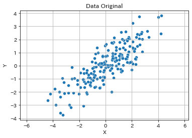

```python
# 1. Generar datos bidimensionales correlacionados (matriz de covarianza definida positiva)
np.random.seed(0)
mean = [0, 0]
cov = [[3, 2], [2, 2]]
X = np.random.multivariate_normal(mean, cov, 200)

# 2. Agrupar en un dataframe y visualizar
data = pd.DataFrame({'X': X[:,0], 'Y': X[:,1]})
sns.scatterplot(x='X', y='Y', data=data)
plt.title("Data Original")
plt.axis('equal')
plt.grid(True)
plt.show()
```

```
🔹 Matriz de correlación:
           X         Y
X  1.000000  0.824383
Y  0.824383  1.000000

🔹 Valores propios:
 [1.82438335 0.17561665]

🔹 Vectores propios:
 [[ 0.70710678 -0.70710678]
 [ 0.70710678  0.70710678]]
```

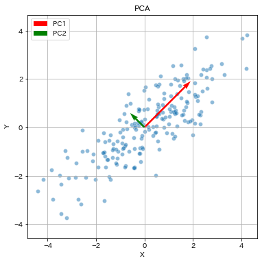

```python
from numpy.linalg import eig

# 3. Matriz de correlación
corr_matrix = data.corr()
print("🔹 Matriz de correlación:\n", corr_matrix)

# 4. Cálculo de los valores propios y vectores propios
eigvals, eigvecs = eig(corr_matrix)
print("\n🔹 Valores propios:\n", eigvals)
print("\n🔹 Vectores propios:\n", eigvecs)

# 5. Trazado de los datos originales y los vectores propios
plt.figure(figsize=(6, 6))
sns.scatterplot(x='X', y='Y', data=data, alpha=0.5)
origin = [0, 0]
colors = ['r', 'g']

# Graficar los vectores propios
for i in range(2):
    vec = eigvecs[:, i]
    # Enfatizar el escalado usando la raíz cuadrada de los valores propios
    scale = np.sqrt(eigvals[i]) * 2
    plt.quiver(*origin, vec[0]*scale, vec[1]*scale, color=colors[i], angles='xy', scale_units='xy', scale=1, label=f'PC{i+1}')

plt.title("PCA")
plt.axis('equal')
plt.grid(True)
plt.legend()
plt.show()
```

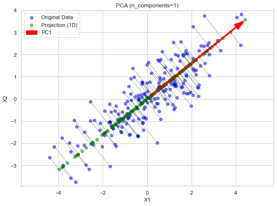

```python
from sklearn.decomposition import PCA

sns.set(style="whitegrid")

# 2. PCA（Usar solo el primer componente principal）
pca = PCA(n_components=1)
X_pca = pca.fit_transform(X)

# 3. Regresar los puntos proyectados al espacio original（1 → 2）
X_proj = pca.inverse_transform(X_pca)

# 4. Gráfico
fig, ax = plt.subplots(figsize=(8, 6))

# Puntos de datos originales （azul）
ax.scatter(X[:, 0], X[:, 1], alpha=0.5, label="Original Data", color="blue")

# Puntos proyectados（verde）
ax.scatter(X_proj[:, 0], X_proj[:, 1], alpha=0.5, label="Projection (1D)", color="green")

# Conectar cada punto con una línea（Originales → Proyectados）
for i in range(len(X)):
    ax.plot([X[i, 0], X_proj[i, 0]], [X[i, 1], X_proj[i, 1]], 'k--', linewidth=0.5)

# Vector del componente principal（flecha roja）
origin = pca.mean_
vec = pca.components_[0] * 5  # Escalado
ax.arrow(origin[0], origin[1], vec[0], vec[1], color='red',
         width=0.05, head_width=0.3, label='PC1')

# Decoración
ax.set_xlabel("X1")
ax.set_ylabel("X2")
ax.set_title("PCA (n_components=1)")
ax.axis("equal")
ax.legend()
plt.tight_layout()
plt.show()
```

## 10.1

あるプロ野球チームの主力選手６人の打撃成績５項目（打率、打点、本塁打、安打数、盗塁数）のデータから、相関係数行列を用いた主成分分析を実施した。表１０．３、表１０．４は、パソコンソフトで計算したものである。以下の設問に答えよ。

1. カイザー基準での主成分の数を求めよ。
2. 第一主成分の因子負荷量を求めよ。

Un equipo de béisbol profesional realizó un análisis de componentes principales utilizando una matriz de coeficientes de correlación basada en los datos de rendimiento de seis jugadores principales, considerando cinco categorías de desempeño (promedio de bateo, carreras impulsadas, jonrones, número de hits y bases robadas). Las tablas 10.3 y 10.4 fueron calculadas usando un software de computadora. Responde a las siguientes preguntas:

1. Determina el número de componentes principales según el criterio de Kaiser.
2. Calcula las cargas factoriales del primer componente principal.

```python
# 認証情報の設定
SERVICE_ACCOUNT_FILE = "my-project-vscode-452201-249bdb033f8c.json"  # JSONファイルのパス
SCOPES = ["https://www.googleapis.com/auth/spreadsheets"]

credentials = Credentials.from_service_account_file(SERVICE_ACCOUNT_FILE, scopes=SCOPES)
client = gspread.authorize(credentials)

# スプレッドシートを開く（URLまたはスプレッドシートIDを使用）
SPREADSHEET_ID = "1RkO0VL4WR6cbPBfBEjz693Lo4SdUAoSvRHV491ggXTo"

sheet = client.open_by_key(SPREADSHEET_ID).worksheet("Sheet7") # 最初のシートを取得

# データを取得
list_of_lists = sheet.get_all_values()
df = pd.DataFrame(list_of_lists)

df.columns = df.iloc[0]
df = df.drop(index=0)
df = df.apply(pd.to_numeric)
```

```python
col = df.columns[1:6].to_list()
nums = ['Primera', 'Segunda', 'Tercera','Cuarta', 'Quinta']
cols=[num + ' componentes principal' for num in nums ]

# Datos de valores propios
eigenvalues = df.iloc[:,0].to_list()

# Calcular la suma de los valores propios
total_eigenvalue = np.sum(eigenvalues)

# Calucular la tasa de contribución y la tasa de contribución
contribution_rate = eigenvalues / total_eigenvalue
cumulative_contribution_rate = np.cumsum(contribution_rate)

data = {
    'Valor propio': eigenvalues,
    'Tasa de contribución': contribution_rate,
    'Tasa de contribución acumulada': cumulative_contribution_rate
}

df2 = pd.DataFrame(data, index=cols)

# Mostrar los resultados
print("Tabla 10.3 : Valor propio y tasa de contribución")

df2
```

```
Tabla 10.3 : Valor propio y tasa de contribución
```

|  | Valor propio | Tasa de contribución | Tasa de contribución acumulada |
| --- | --- | --- | --- |
| Primera componentes principal | 3.175 | 0.6350 | 0.6350 |
| Segunda componentes principal | 1.065 | 0.2130 | 0.8480 |
| Tercera componentes principal | 0.442 | 0.0884 | 0.9364 |
| Cuarta componentes principal | 0.317 | 0.0634 | 0.9998 |
| Quinta componentes principal | 0.001 | 0.0002 | 1.0000 |

Según el **criterio de Kaiser**, se seleccionan los componentes principales con valores propios superiores a uno.

Por lo tanto, según la Tabla 10.3, el **número de componentes principales es 2**.

```python
# Datos de vectores propios
eigenvectors = df.iloc[:,1:6].T.to_numpy()

# Determinar el número de componentes
num_components = 0
for item in eigenvalues:
  if item >= 1:
    num_components += 1

# Mostrar los resultados
print("Número de componentes principales basado en el criterio de Kaiser:", num_components)

df4 = pd.DataFrame(eigenvectors, columns=cols, index=col)

# Mostrar los resultados
print("\nTabla 10.4: Vector propio")
df4
```

```
Número de componentes principales basado en el criterio de Kaisar: 2

Tabla 10.4: Vector propio
```

|  | Primera componentes principal | Segunda componentes principal | Tercera componentes principal | Cuarta componentes principal | Quinta componentes principal |
| --- | --- | --- | --- | --- | --- |
| Promedio de bateo | 0.464 | -0.157 | 0.697 | 0.491 | 0.182 |
| Carreras impulsadas | 0.534 | -0.099 | -0.294 | -0.374 | 0.691 |
| Jonorones | 0.485 | -0.433 | 0.032 | -0.404 | -0.642 |
| Número de hits | 0.455 | 0.305 | -0.568 | 0.564 | -0.245 |
| Número de bases robadas | 0.239 | 0.828 | 0.323 | -0.370 | -0.128 |

Dado que los signos de los vectores propios del primer componente principal son todos iguales, este puede interpretarse como un **índice compuesto** (o puntuación global).

El valor propio del primer componente principal es 3.175, por lo que las cargas factoriales se muestran en la Tabla 10.5.

```python
# Calcular la raiz cuadrada de los valores propios
eigenvalues_sqrt = np.sqrt(eigenvalues)

# Calcular las cargas factoriales
factor_loadings = eigenvectors * eigenvalues_sqrt

# Mostrar los resultados como un DataFrame
df3 = pd.DataFrame(factor_loadings, columns=cols, index=col)

# Mostrar los resultados
print("\nTabla 10.5 Carga factorial del componente principal")
df3
```

```
Tabla 10.5 Carga factorial del componente principal
```

|  | Primera componentes principal | Segunda componentes principal | Tercera componentes principal | Cuarta componentes principal | Quinta componentes principal |
| --- | --- | --- | --- | --- | --- |
| Promedio de bateo | 0.826780 | -0.162022 | 0.463387 | 0.276447 | 0.005755 |
| Carreras impulsadas | 0.951509 | -0.102167 | -0.195460 | -0.210572 | 0.021851 |
| Jonorones | 0.864199 | -0.446851 | 0.021275 | -0.227463 | -0.020302 |
| Número de hits | 0.810743 | 0.314756 | -0.377624 | 0.317548 | -0.007748 |
| Número de bases robadas | 0.425863 | 0.854486 | 0.214740 | -0.208320 | -0.004048 |

## 4. Análisis discriminante

判別分析

**Análisis discriminante** es un método que, basado en datos divididos en varios grupos (categorías), permite **determinar a qué grupo pertenece** una **nueva muestra**.

[Audio_5](https://drive.google.com/file/d/1PuPZsfF4eQwp63ksVNIxYhxxqyKqE_LB/view?usp=drive_link)

## 10.2

１６名の学生について、ある科目の事前の試験勉強時間と試験の合否を調査したところ、下記（表１０．７）となった。以下の設問に答えよ。ただし、勉強時間は正規分布に従っており、合格者と不合格で分散は同じとする。

1. 合格者と不合格者を判別するための線形判別式を求めよ。
2. 求めた判別式での誤判定率を求めよ。

Se investigó el tiempo de estudio previo al examen de una determinada materia y los resultados del examen de 16 estudiantes, obteniéndose los siguiente datos (Tabla 10.7). Responda las siguientes preguntas. Suponga que el tiempo de estudio sigue una distribución normal y que la varianza es la misma tanto para los aprobados como para los reprobados.

1. Determine la función discriminante lineal para distinguir entre los estudiantes aprobados y reprobados.
2. Calcule la tasa de error de clasificación utilizando la función discriminante obtenida.

```python
sheet = client.open_by_key(SPREADSHEET_ID).worksheet("Sheet8") # 最初のシートを取得

# データを取得
list_of_lists = sheet.get_all_values()
df = pd.DataFrame(list_of_lists)
df = df.T

df.columns = df.iloc[0]
df = df.drop(index=0)
df = df.set_index(df.columns[0])
df.iloc[:,0] = df.iloc[:,0].apply(pd.to_numeric)
df.columns = ['Tiempo de estudio','Resultado']
df['Resultado'] = df['Resultado'].replace({'合格': 'Aprobado', '不合格': 'Reprobado'})
```

```python
print('Tabla 10.7 Tiempo de estudio y Resultado')
df.T
```

```
Tabla 10.7 Tiempo de estudio y Resultado
```

|  | 1 | 2 | 3 | 4 | 5 | 6 | 7 | 8 | 9 | 10 | 11 | 12 | 13 | 14 | 15 | 16 |
| --- | --- | --- | --- | --- | --- | --- | --- | --- | --- | --- | --- | --- | --- | --- | --- | --- |
| Tiempo de estudio | 30 | 16 | 6 | 24 | 12 | 15 | 10 | 20 | 16 | 25 | 7 | 12 | 15 | 24 | 19 | 18 |
| Resultado | Aprobado | Reprobado | Reprobado | Aprobado | Aprobado | Reprobado | Reprobado | Aprobado | Reprobado | Aprobado | Reprobado | Reprobado | Aprobado | Reprobado | Aprobado | Aprobado |

$ \hat{\mu} = (\bar{x}_A + \bar{x}_B)/2 = 16.813 $

$ S_A = \sum x_A^2 - (\sum x_A)^2 / n_A = 233.875 $

$ S_B = \sum x_B^2 - (\sum x_B)^2 / n_B = 237.500 $

$ \hat{\sigma}^2 = (V_A + V_B)/2 = 33.670 $

```python
# 各グループの統計量を計算
grouped = df.groupby('Resultado')['Tiempo de estudio']

# 平均、分散、件数を求める
mean = grouped.mean()
var = grouped.var()
count = grouped.count()

# 平方和を計算： SS = var * (n - 1)
ss = var * (count - 1)

# DataFrameにまとめる
stats_df = pd.DataFrame({
    'mean': mean,
    'var': var,
    'sum of squares (SS)': ss
})

stats_df.rename(index={"Aprobado": 'Aprobado(B)', "Reprobado": 'Reprobado(A)'}, inplace=True)
stats_df.loc['mean'] = stats_df.mean()

print(stats_df)
```

```
                 mean        var sum of squares (SS)
Resultado
Aprobado(B)    20.375  33.410714             233.875
Reprobado(A)    13.25  33.928571               237.5
mean          16.8125  33.669643            235.6875
```

$ D_B^2 - D_A^2 = (\hat{\mu}_A - \hat{\mu}_B) / \sigma^2 \cdot (x - \bar{\mu}) $

$ \qquad = 0.212 x - 3.558 $

```python
from sklearn.discriminant_analysis import LinearDiscriminantAnalysis as LDA
from sklearn.metrics import accuracy_score

# Conversión de resultado a valor numérico（Aprobado: 1, Reprobado: 0）
df['Resultado'] = df['Resultado'].map({'Aprobado': 1, 'Reprobado': 0})

# Separación de características y objetivo
X = df[['Tiempo de estudio']]
y = df['Resultado']

# Aplicación de modelo de Análisis Discriminante Lineal (LDA)
lda = LDA()
lda.fit(X, y)

# Coeficiente e intercepto de la función discriminante
coef = lda.coef_[0][0]
intercept = lda.intercept_[0]
print(f"Función discriminante lineal: y = {coef:.3f} * x + {intercept:.3f}")

# Predicción del modelo
predictions = lda.predict(X)

# Cálculo de la tasa de error de clasificación
accuracy = accuracy_score(y, predictions)
misclassification_rate = 1 - accuracy

print(f"Tasa de erro: {misclassification_rate:.4f}")
```

```
Función discriminante linear: y = 0.212 * x + -3.558
Tasa de erro: 0.1875
```

La función de discriminate:

$ (D_B^2 - D_A^2) = 0 \qquad $ cuando $ x = 16.813 $

La tasa de error de clasificación:

$ (2+1)/16 \times 100 = 18.75 $(%)

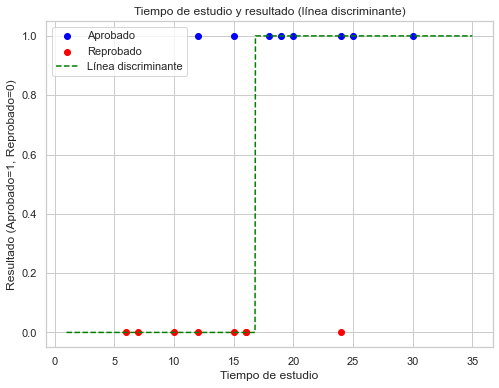

```python
# Representar el diagrama de dispersión
plt.figure(figsize=(8, 6))
plt.scatter(df['Tiempo de estudio'][df['Resultado'] == 1], [1] * len(df[df['Resultado'] == 1]), color='blue', label='Aprobado')
plt.scatter(df['Tiempo de estudio'][df['Resultado'] == 0], [0] * len(df[df['Resultado'] == 0]), color='red', label='Reprobado')

# Construcción de la línea discriminante
# Cálculo de la frontera de decisión para LDA
x_values = np.linspace(df['Tiempo de estudio'].min() - 5, df['Tiempo de estudio'].max() + 5, 1000)
x_values_df = pd.DataFrame(x_values, columns=['Tiempo de estudio'])
y_values = lda.predict(x_values_df)

# Representar la línea discriminante
plt.plot(x_values, y_values, color='green', linestyle='--', label='Línea discriminante')

# Configuración del gráfico
plt.title('Tiempo de estudio y resultado (línea discriminante)')
plt.xlabel('Tiempo de estudio')
plt.ylabel('Resultado (Aprobado=1, Reprobado=0)')
plt.legend(loc='best')
plt.grid(True)
plt.show()
```

### 5. Análisis de clúster

クラスター分析

El **análisis de clúster** es un método que, basado en la **similitud** o **disimilitud**, agrupa grandes conjuntos de datos. Consiste en agrupar elementos similares en varios grupos (clústeres).

- Análisis de clúster jerárquico
- Análisis de clúster no jerárquico

[Audio_6](https://drive.google.com/file/d/1PP9sOYsCG9nbLCvHE6047IqMvwFBXTRd/view?usp=drive_link)

## Dendrograma (clustering jerárquico)

Agrupa los datos similares para formar clusters y crea un dendrograma.

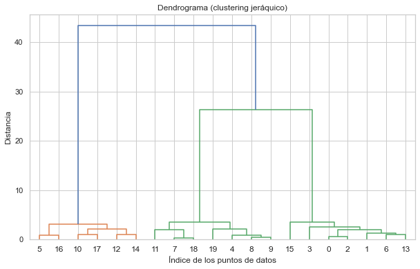

```python
from scipy.cluster.hierarchy import dendrogram, linkage, fcluster
from sklearn.datasets import make_blobs

# データ生成（視覚的に分かりやすいクラスタ）
X, y_true = make_blobs(n_samples=20, centers=3, cluster_std=1.0, random_state=42)

# 距離とクラスタ結合の履歴を計算（Ward法）
Z = linkage(X, method='ward')

# 図1: デンドログラム
plt.figure(figsize=(10, 6))
dendrogram(Z)
plt.title("Dendrograma (clustering jeráquico)")
plt.xlabel("Índice de los puntos de datos")
plt.ylabel("Distancia")
plt.grid(True)
plt.show()
```

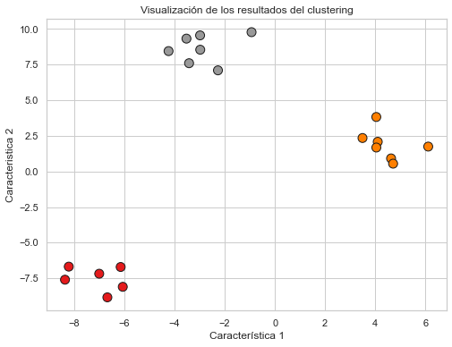

```python
# 図2: 元データとクラスタ結果（色で表示）
# クラスタ数（ここでは3）で切る
clusters = fcluster(Z, t=3, criterion='maxclust')

# プロット
plt.figure(figsize=(8, 6))
plt.scatter(X[:, 0], X[:, 1], c=clusters, cmap='Set1', s=100, edgecolors='k')
plt.title("Visualización de los resultados del clustering")
plt.xlabel("Característica 1")
plt.ylabel("Caracteristica 2")
plt.grid(True)
plt.show()
```

## K-means Clastering

Es un método que, a diferencia del clustering jerárquico, no presenta una estructura de árbol. En su lugar, se define de antemano el número de clusters y los datos se agrupan en esa cantidad preestablecida.

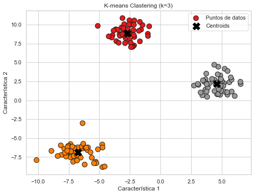

```python
from sklearn.datasets import make_blobs
from sklearn.cluster import KMeans

# クラスタ数 = 3、サンプル数 = 150 の2次元データを生成
X, y_true = make_blobs(n_samples=150, centers=3, cluster_std=1.0, random_state=42)

# k-means クラスタリング
kmeans = KMeans(n_clusters=3, random_state=42)
kmeans.fit(X)
y_kmeans = kmeans.predict(X)
centroids = kmeans.cluster_centers_

# プロット
plt.figure(figsize=(8, 6))
plt.scatter(X[:, 0], X[:, 1], c=y_kmeans, s=100, cmap='Set1', edgecolors='k', label='Puntos de datos')
plt.scatter(centroids[:, 0], centroids[:, 1], c='black', s=200, marker='X', label='Centroids')
plt.title("K-means Clastering (k=3)")
plt.xlabel("Característica 1")
plt.ylabel("Característica 2")
plt.legend()
plt.grid(True)
plt.show()
```

## Por favor, responda a las preguntas del examen de práctica a través del siguiente enlace.

[Simulacro de examen](https://forms.gle/1JPU5VwvT2HtEvy86)

## 15.2

10人の生徒に、国語、英語、数学、理科の学力テストを行い表15.2の結果が得られた。この成績の特徴を分析するため、このデータに対して主成分分析をおこなう。

Se realizó una prueba de habilidades en Lengua, inglés, matemáticas, y ciencias a 10 estudiantes, y se obtuvo el resultado en la tabla 15.2. Para analizar las características de estos resultados, se llevará a cabo un análisis de componentes principales sobre estos datos.

```python
# スプレッドシートを開く（URLまたはスプレッドシートIDを使用）
SPREADSHEET_ID = "1Ma7ehT4TAnkUwJjspP-C3mwJA1hYmbJr8B9GJSFI0lU"

sheet = client.open_by_key(SPREADSHEET_ID).worksheet("Sheet1") # 最初のシートを取得

# データを取得
list_of_lists = sheet.get_all_values()
df = pd.DataFrame.from_records(list_of_lists)
df.columns = df.iloc[0]
df = df.drop(index=0)

df.set_index("Alu", inplace=True)
df = df.apply(pd.to_numeric)
df2 = df.copy()

# 各列の平均と標準偏差を計算し最終行に追加
df2.loc["mean"] = np.round(df2.mean(),1)
df2.loc["std"] = np.round(df2.std(),2)

df2.to_excel("Data_1/15_1.xlsx",index=False)
print("Tabla 15.1 Datos (puntajes de 100 puntos en cada materia)")
print(df2)
```

```
Tabla 15.1 Datos (puntajes de 100 puntos en cada materia)
0      Leng   Ing    Mat   Cien
Alu
1     48.00  38.0  57.00  60.00
2     53.00  43.0  59.00  64.00
3     62.00  68.0  63.00  83.00
4     77.00  85.0  61.00  59.00
5     65.00  74.0  54.00  51.00
6     47.00  48.0  51.00  59.00
7     66.00  66.0  47.00  61.00
8     35.00  39.0  52.00  58.00
9     66.00  67.0  47.00  58.00
10    56.00  41.0  48.00  48.00
mean  57.50  56.9  53.90  60.10
std   11.53  16.1   5.58   8.84
```

```python
from sklearn.decomposition import PCA
from sklearn.preprocessing import StandardScaler

# Estandarización de los datos
scaler = StandardScaler()
scaled_data = scaler.fit_transform(df)

# Ejecución del análisis de componentes principales（PCA）
pca = PCA()
pca.fit(scaled_data)

# Valores propios (varianzas) de cada componente principal
# Vectores propios
eigenvalues = pca.explained_variance_  # Vectores propios
explained_variance_ratio = pca.explained_variance_ratio_  # Tasa de contribución
cumulative_variance_ratio = np.cumsum(explained_variance_ratio)  # Tasa de contribución acumulada
eigenvectors = pca.components_.T  # Vectores propios

# Organizar los resultados en un DAtaFrame
results = pd.DataFrame({
    'Valor propio': eigenvalues,
    'Tasa de contribución acumulada': cumulative_variance_ratio
}, index=[f'PC{i+1}' for i in range(len(eigenvalues))])

# Agregar los vectores propios
eigenvectors_df = pd.DataFrame(eigenvectors, columns=[f'PC{i+1}' for i in range(len(eigenvalues))], index=df.columns)

df2 = pd.merge(results, eigenvectors_df.T, left_index=True, right_index=True)
df2 = df2.round(3)

df2.to_excel("Data_1/15_2.xlsx")

#
print("Tabla 15.2 Resultados del análisis")
df2
```

```
Tabla 15.2 Resultados del análisis
```

|  | Valor propio | Tasa de contribución acumulada | Leng | Ing | Mat | Cien |
| --- | --- | --- | --- | --- | --- | --- |
| PC1 | 2.315 | 0.521 | 0.576 | 0.611 | 0.406 | 0.362 |
| PC2 | 1.595 | 0.880 | -0.424 | -0.343 | 0.568 | 0.616 |
| PC3 | 0.419 | 0.974 | 0.012 | -0.075 | 0.716 | -0.694 |
| PC4 | 0.116 | 1.000 | -0.699 | 0.710 | 0.002 | -0.087 |

第一主成分と第二主成分に集約して、主成分得点と因子負荷量の散布図を作成する。

Agrupar en el primer y segundo componente principal, y crear un diagrama de dispersión de las puntuaciones de los componentes principales y las cargas factoriales.

```
Resultados del análisis de componentes principalse:
Porcentaje de varianza explicada: [0.52076433 0.35892575]

Cargas factoriales:
           PC1       PC2
0
Leng  0.876211 -0.535480
Ing   0.928885 -0.433048
Mat   0.617266  0.718009
Cien  0.550379  0.778086
```

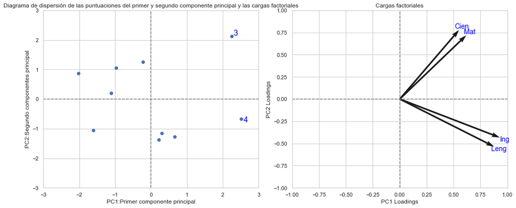

```python
# Ejecución del análisis de componentes principales (PCA)
pca = PCA(n_components=2)
principal_components = pca.fit_transform(scaled_data)

# Puntuaciones de los componentes principales
pc_df = pd.DataFrame(data=principal_components, columns=['PC1', 'PC2'])
pc_df.to_excel('Data_1/pc_df.xlsx', index=False)

# Cargas factoriales
loadings = pca.components_.T * np.sqrt(pca.explained_variance_)
loading_df = pd.DataFrame(data=loadings, columns=['PC1', 'PC2'], index=df.columns)
loading_df.to_excel('Data_1/loading_df.xlsx')

#
print("Resultados del análisis de componentes principales:")
print("Porcentaje de varianza explicada:", pca.explained_variance_ratio_)
print("\nCargas factoriales:")
print(loading_df)
print("\n")

# Creación del diagrama de dispersión
fig, ax = plt.subplots(1, 2, figsize=(14, 6))

# Obtener el número de estudiantes con los valores máximos del primer y
# segundo componentes principal y agregarlo al gráfico
a = pc_df['PC1'].idxmax()
b = pc_df['PC2'].idxmax()

# Diagrama de dispersión de las puntuaciones del primer y segundo componentes principal
ax[0].scatter(pc_df['PC1'], pc_df['PC2'])
for i in range(len(pc_df)):
  if i in [a,b]:
    ax[0].text(pc_df['PC1'].iloc[i]*1.05,
               pc_df['PC2'].iloc[i]*1.05,
               df.index[i], ha='center', va='center',
               fontsize=16, color='blue')

ax[0].axhline(0, color='gray', linestyle='--')
ax[0].axvline(0, color='gray', linestyle='--')
ax[0].set_xlim(-3, 3)
ax[0].set_ylim(-3, 3)
ax[0].set_xlabel('PC1:Primer componente principal')
ax[0].set_ylabel('PC2:Segundo componentes principal')
ax[0].set_title('Diagrama de dispersión de las puntuaciones del primer y segundo componente principal y las cargas factoriales')

# Diagrama de dispersión de las puntuaciones del primer y segundo componente principal
# y las cargas factoriales
ax[1].quiver(np.zeros(len(loading_df)), np.zeros(len(loading_df)), loading_df['PC1'], loading_df['PC2'], angles='xy', scale_units='xy', scale=1)
for i in range(len(loading_df)):
    ax[1].text(loading_df['PC1'].iloc[i]*1.05,
               loading_df['PC2'].iloc[i]*1.05,
               loading_df.index[i], ha='center', va='center',
               fontsize=14, color='blue')

ax[1].axhline(0, color='gray', linestyle='--')
ax[1].axvline(0, color='gray', linestyle='--')
ax[1].set_xlim(-1, 1)
ax[1].set_ylim(-1, 1)
ax[1].set_xlabel('PC1 Loadings')
ax[1].set_ylabel('PC2 Loadings')
ax[1].set_title('Cargas factoriales')

plt.tight_layout()
plt.show()
```

```python
notebook_name = 'QCKentei1-10.ipynb'
notebook_name_html = notebook_name.replace(".ipynb",".html")

!jupyter nbconvert --to html {notebook_name}
```

```
[NbConvertApp] Converting notebook QCKentei1-10.ipynb to html
[NbConvertApp] Writing 990362 bytes to QCKentei1-10.html
```